# PanCan IRWG Tumor Clonality Correlation within Immune Subytpes

James A. Eddy

2017-05-19

# Summary

Exploring associations of tumor clonality across immune subtypes in TCGA with suggested correlates defined by the Immune Response Working Group:

- Overall Leukocyte fraction
- Individual Relative CIBERSORT fraction
- Mutation Load
- TCR,BCR Diversity
- Gene expression

# Prepare data

## Retrieve clonality data from Synapse

Data are stored on Synapse in the folder `syn4602485` for “Aneuploidy and Copy number”.

Aneuploidy and Copy number: syn4602485 syn7300639 (“Purity_Ploidy_All_Samples_9_28_16.tsv”) filename: “TCGA_mastercalls.abs_tables_JSedit.fixed.txt”

```r
if (!dir.exists("../data")) {
    dir.create("../data")
}
synapseLogin()
```

```
Welcome jaeddy!
```

```r
# # file_data <- synGet("syn7300639", downloadLocation = "./data/tcga")
# clonality_file <- "../data/tcga/TCGA_mastercalls.abs_tables_JSedit.fixed.txt"
# clonality_df <- read_tsv(clonality_file)
```

```r
panimmune_fm_file <- "../data/tcga/PanImmune_FeatureMatrix_20170505.tsv"
panimmune_fm_df <- read_tsv(panimmune_fm_file)
```

## Sample filtering

Sample Quality Annotations: syn4551248 (“merged_sample_quality_annotations.tsv”)

```r
sample_qual_file <- synGet("syn4551248", downloadLocation = "../data/tcga/")
sample_qual_df <- sample_qual_file %>%
    getFileLocation() %>%
    read_tsv()
```

Remove samples based on `Do_not_use=True`, and remove cases with `AWG_excluded_because_of_pathology=True`.

```r
# samples to exclude from all datasets
exclude_samples <- sample_qual_df %>%
    mutate(AWG_excluded_because_of_pathology = parse_logical(AWG_excluded_because_of_pathology),
           Do_not_use = parse_logical(str_to_upper(Do_not_use))) %>%
    filter(AWG_excluded_because_of_pathology | Do_not_use)
```

Remove samples from clonality dataset, add disease types. Also remove samples with missing values for subclonal faction. Add additional column to store vial ID (to ease mapping between data sets).

```r
clonality_corr_df <- clonality_df %>%
    filter(!(sample %in% exclude_samples$aliquot_barcode),
           !is.na(`Subclonal genome fraction`)) %>%
    left_join(sample_qual_df %>%
                  select(aliquot_barcode, `cancer type`),
              by = c("sample" = "aliquot_barcode")) %>%
    mutate(vial_id = str_replace(sample, "(\\-[:alnum:]+){3}$", ""))
```

Remove samples from feature matrix based on quality filters. Also remove samples with missing values for subclonal fraction, leukocyte fraction, or immune subtype.

```r
clonality_subtype_corr_df <- panimmune_fm_df %>%
    filter(!(Representative_Expression_Matrix_AliquotBarcode %in% exclude_samples$aliquot_barcode)) %>%
    filter(!is.na(Subtype_Immune_Model_Based),
           !is.na(leukocyte_fraction),
           !is.na(Subclonal_genome_fraction))
```

## Subset correlates

Drop some of the variables that won’t be used for correlation tests with clonality.

```r
# names(clonality_subtype_corr_df)
demographics <- c("gender", "age_at_initial_pathologic_diagnosis", "ethnicity",
                  "height", "weight")
survival_vars <- c("OS", "OS_time", "PFI_1", "PFI_time_1")
xcr_nonshannon_vars <- c("totTCR_reads", "BCR_evenness_by_seq", "BCR_num_unique_seq")
nonmodel_subtypes <- c("Subtype_Curated_Malta_Noushmehr_et_al",
                       "Study_Histological_Subtype", "Major_Histological_Type")
indel_neoantigens <- c("indel_num", "indel_neoantigen_num")
gene_set_scores <- c("Module3_IFN_score", "TGFB_score_21050467", "CSF1_response",
                     "CHANG_CORE_SERUM_RESPONSE_UP", "LIexpression_score")
cibersort_aggregates <- names(clonality_subtype_corr_df) %>%
    str_extract(".*Aggregate.*") %>%
    na.omit() %>%
    as.character()
th_sig_scores <- c("Th1.cells", "Th17.cells", "Th2.cells")
cna_vars <- c("AS", "AS_prime", "LOH_n_seg", "LOH_frac_altered",
              "HRD", "n_segs", "frac_altered")
stemness_vars <- c("StemnessScoreRNA", "StemnessScoreDNA")
viral_expression <- names(clonality_subtype_corr_df) %>%
    str_extract(".*V_Normalized_RPM") %>%
    na.omit() %>%
    as.character()
other_expression_scores <- c("CD103pos_CD103neg_ratio_25446897",
                             "CD103pos_mean_25446897", "Module11_Prolif_score")
exclude_variables <- c(demographics, survival_vars, xcr_nonshannon_vars,
                       nonmodel_subtypes, indel_neoantigens, gene_set_scores,
                       cibersort_aggregates, th_sig_scores,
                       cna_vars, stemness_vars,
                       viral_expression, other_expression_scores)
clonality_subtype_corr_sub_df <- clonality_subtype_corr_df %>%
    select(-one_of(exclude_variables))
```

## Expand immunomodulator expression

### Load and transpose expression data

```r
mrna_immunomod_file <- "../data/intermediate/mrna_immunomodulators.feather"
mrna_immunomod_df <- read_feather(mrna_immunomod_file)
mrna_immunomod_tr_df <- mrna_immunomod_df %>%
    select(-gene_name) %>%
    t() %>%
    as.data.frame() %>%
    set_names(mrna_immunomod_df$gene_name) %>%
    rownames_to_column("vial_id") %>%
    slice(-1)
```

### Merge with correlate table

```r
clonality_subtype_master_corr_df <- clonality_subtype_corr_sub_df %>%
    mutate(id = Representative_Expression_Matrix_AliquotBarcode,
           vial_id = str_replace(id, "(\\-[:alnum:]+){3}$", "")) %>%
    select(-CD274, -CTLA4, -PDCD1) %>%
    left_join(mrna_immunomod_tr_df, by = "vial_id")
```

# Explore ITH distributions

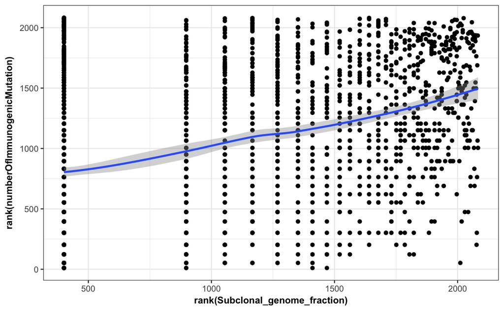

```r
clonality_subtype_master_corr_df %>%
    filter(Subtype_Immune_Model_Based == "C3") %>%
    ggplot(aes(x = rank(Subclonal_genome_fraction), y = rank(numberOfImmunogenicMutation))) +
    geom_point() +
    stat_smooth(method="loess")
```

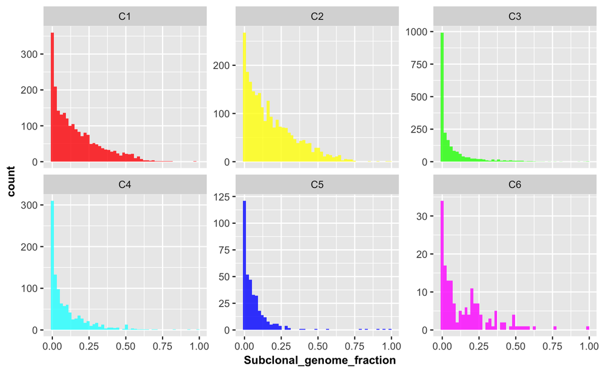

```r
clonality_subtype_master_corr_df %>%
    ggplot(aes(x = Subclonal_genome_fraction)) +
    geom_histogram(aes(fill = Subtype_Immune_Model_Based), bins = 50, alpha = 0.8) +
    scale_fill_manual(values = c("red", "yellow", "green", "cyan", "blue", "magenta")) +
    facet_wrap(~ Subtype_Immune_Model_Based, scales = "free_y") +
    guides(fill = FALSE) +
    theme_gray()
```

```r
table(clonality_subtype_master_corr_df$Subclonal_genome_fraction == 0)
```

```
FALSE  TRUE
 6738  1567
```

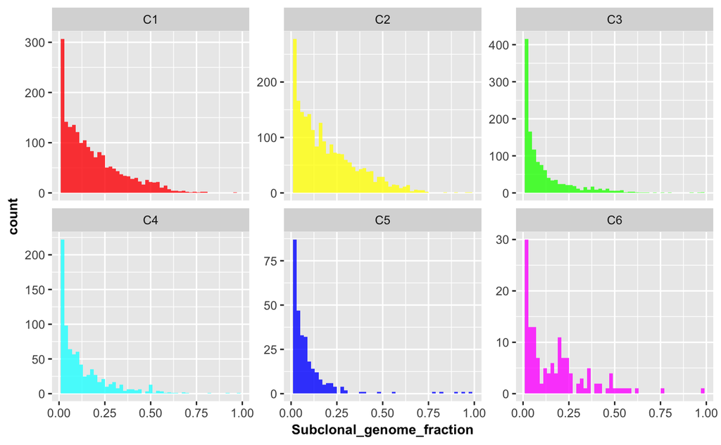

```r
clonality_subtype_master_corr_df %>%
    filter(Subclonal_genome_fraction > 0) %>%
    ggplot(aes(x = Subclonal_genome_fraction)) +
    geom_histogram(aes(fill = Subtype_Immune_Model_Based), bins = 50, alpha = 0.8) +
    scale_fill_manual(values = c("red", "yellow", "green", "cyan", "blue", "magenta")) +
    facet_wrap(~ Subtype_Immune_Model_Based, scales = "free_y") +
    guides(fill = FALSE) +
    theme_gray()
```

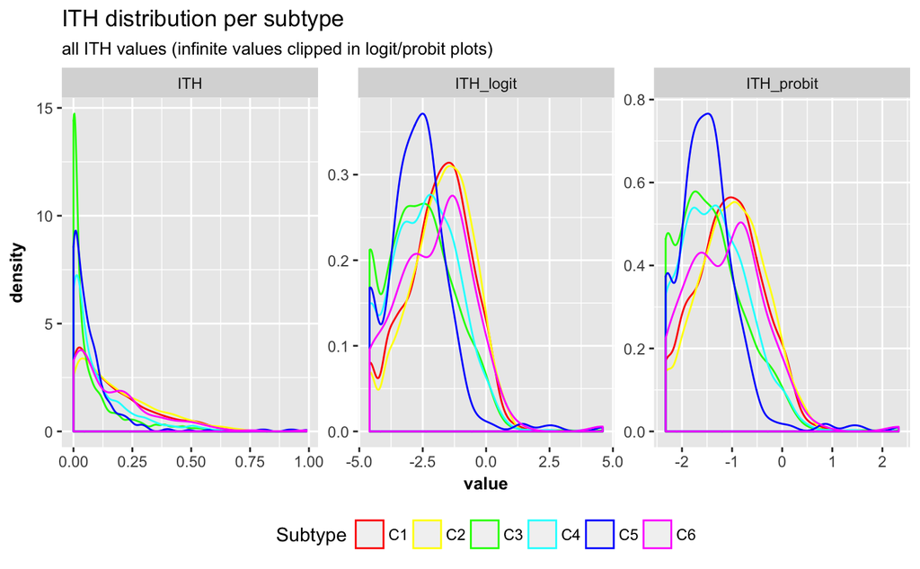

```r
p <- clonality_subtype_master_corr_df %>%
    # filter(Subclonal_genome_fraction > 0) %>%
    select(ITH = Subclonal_genome_fraction, Subtype = Subtype_Immune_Model_Based) %>%
    mutate(ITH_probit = qnorm(ITH),
           ITH_logit = log(ITH / (1 - ITH))) %>%
    gather(transform, value, -Subtype) %>%
    ggplot(aes(x = value)) +
    geom_density(aes(colour = Subtype)) +
    scale_colour_manual(values = c("red", "yellow", "green", "cyan", "blue", "magenta")) +
    guides(fill = FALSE, colour = guide_legend(nrow = 1)) +
    theme_gray() +
    theme(legend.position = "bottom") +
    facet_wrap(~ transform, nrow = 1, scales = "free") +
    ggtitle("ITH distribution per subtype",
            "all ITH values (infinite values clipped in logit/probit plots)")
p
ggsave("../ith_all_dists.png", p, width = 6, height = 3.5)
```

# Compute correlation stats

For each immune subtype, correlate clonality (subclonal genome fraction) against all other variables using Spearman.

```r
clonality_subtype_spearman_df <- clonality_subtype_master_corr_df %>%
    filter((!Study %in% c("LAML", "THYM", "DLBC"))) %>%
    select(-ParticipantBarcode, -Study, -vial_id, -id,
           -Representative_Expression_Matrix_AliquotBarcode) %>%
    group_by(Subtype_Immune_Model_Based) %>%
    nest() %>%
    mutate(data = map(data, function(subtype_df) {
        subtype_df %>%
            gather(correlate, x, -Subclonal_genome_fraction, convert = FALSE) %>%
            group_by(correlate) %>%
            do(tidy(cor.test(.$Subclonal_genome_fraction, .$x,
                             method = "spearman"))) %>%
            ungroup()
    })) %>%
    unnest(data)
clonality_subtype_spearman_df[["p.adjust"]] <- clonality_subtype_spearman_df %>%
    .[["p.value"]] %>%
    p.adjust(method = "BH")
```

```r
clonality_subtype_regression_df <- clonality_subtype_master_corr_df %>%
    filter((!Study %in% c("LAML", "THYM", "DLBC"))) %>%
    select(-ParticipantBarcode, -Study, -vial_id, -id,
           -Representative_Expression_Matrix_AliquotBarcode) %>%
    group_by(Subtype_Immune_Model_Based) %>%
    nest() %>%
    mutate(data = map(data, function(subtype_df) {
        subtype_df %>%
            # mutate(ith_logit = log(Subclonal_genome_fraction / (1-Subclonal_genome_fraction))) %>%
            # select(-Subclonal_genome_fraction) %>%
            gather(correlate, x, -Subclonal_genome_fraction, convert = FALSE) %>%
            group_by(correlate) %>%
            # do(tidy(lm(ith_logit ~ x, data = .))) %>%
            do(tidy(glm(Subclonal_genome_fraction ~ x,
                        family = binomial(link = "probit"),
                        data = .))) %>%
            ungroup()
    })) %>%
    unnest(data)
# clonality_subtype_spearman_df[["p.adjust"]] <- clonality_subtype_spearman_df %>%
#     .[["p.value"]] %>%
#     p.adjust(method = "BH")
```

# Summarize results

```r
get_cet_pal <- function(cet_path) {
    read_lines(cet_path) %>%
        as.list() %>%
        map_chr(function(c) {
            c_rgb <- str_split_fixed(string = c, pattern = ",", n = 3)
            rgb(c_rgb[1], c_rgb[2], c_rgb[3], maxColorValue = 255)
        })
}
# here's an example with the diverging blue-to yellow colormap:
cet_path <- "~/Downloads/CETperceptual_csv_0_255/diverging-linear_bjy_30-90_c45_n256.csv"
my_cet_pal <- get_cet_pal(cet_path)
```

```r
correlate_type_levels <- c("Cell Content", "Immune Cell Fraction",
                           "Mutation Load", "Neoantigen Load",
                           "TCR/BCR Diversity", "Immunomodulator Expression")
correlate_key <- clonality_subtype_spearman_df %>%
    distinct(correlate) %>%
    mutate(correlate_type = case_when(
        str_detect(.$correlate, "mutationrate") ~ "Mutation Load",
        str_detect(.$correlate, "numberOf") ~ "Neoantigen Load",
        str_detect(str_to_lower(.$correlate), "_fraction") ~ "Cell Content",
        str_detect(.$correlate, "(TCR|BCR)") ~ "TCR/BCR Diversity"
    ),
    correlate_type = if_else(is.na(correlate_type) &
                                 correlate %in% mrna_immunomod_df$gene_name,
                             "Immunomodulator Expression", correlate_type),
    correlate_type = if_else(is.na(correlate_type) &
                                 correlate %in% c("CD68", "CD8A", "TREM1"),
                             "Immunomodulator Expression", correlate_type),
    correlate_type = if_else(is.na(correlate_type),
                             "Immune Cell Fraction", correlate_type),
    correlate_type = factor(correlate_type, levels = correlate_type_levels)
    )
```

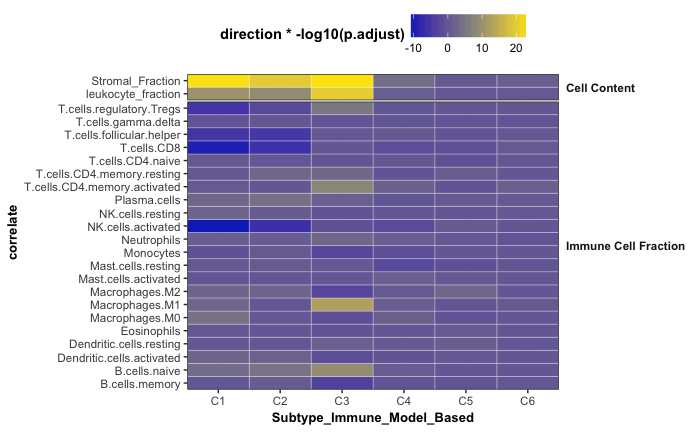

```r
p <- clonality_subtype_spearman_df %>%
    left_join(correlate_key, by = "correlate") %>%
    mutate(direction = ifelse(estimate >= 0, 1, -1)) %>%
    filter(correlate_type %in% c("Cell Content", "Immune Cell Fraction")) %>%
    ggplot(aes(y = correlate, x = Subtype_Immune_Model_Based)) +
    # geom_tile(aes(fill = estimate)) +
    geom_tile(aes(fill = direction * -log10(p.adjust)), colour = "white") +
    scale_fill_gradientn(colours = my_cet_pal) +
    scale_x_discrete(expand = c(0, 0)) +
    scale_y_discrete(expand = c(0, 0)) +
    facet_grid(correlate_type ~ ., scales = "free_y", space = "free_y") +
    theme(legend.position = "top",
          strip.text.x = element_text(face = "bold", angle = 0, hjust = 0),
          strip.text.y = element_text(angle = 0, face = "bold", hjust = 0),
          strip.background = element_blank(),
          panel.spacing.y = unit(1, "points"))
p
ggsave("../ith_infiltrate_corr.png", width = 5, height = 5)
```

## Set up plotting colors

```r
tcga_colors <- tribble(
    ~Color, ~Disease,
    "#ED2891", "BRCA",
    "#B2509E", "GBM",
    "#D49DC7", "LGG",
    "#C1A72F", "ACC",
    "#E8C51D", "PCPG",
    "#F9ED32", "THCA",
    "#104A7F", "CHOL",
    "#9EDDF9", "COAD",
    "#007EB5", "ESCA",
    "#CACCDB", "LIHC",
    "#6E7BA2", "PAAD",
    "#DAF1FC", "READ",
    "#00AEEF", "STAD",
    "#F6B667", "CESC",
    "#D97D25", "OV",
    "#FBE3C7", "UCEC",
    "#F89420", "UCS",
    "#97D1A9", "HNSC",
    "#009444", "UVM",
    "#754C29", "LAML",
    "#CEAC8F", "THYM",
    "#3953A4", "DLBC",
    "#BBD642", "SKCM",
    "#00A99D", "SARC",
    "#D3C3E0", "LUAD",
    "#A084BD", "LUSC",
    "#542C88", "MESO",
    "#FAD2D9", "BLCA",
    "#ED1C24", "KICH",
    "#F8AFB3", "KIRC",
    "#EA7075", "KIRP",
    "#7E1918", "PRAD",
    "#BE1E2D", "TGCT"
)

tcga_colors <- tcga_colors %>%
    filter((!Disease %in% c("LAML", "THYM", "DLBC")))

clonality_corr_df <- clonality_corr_df %>%
    dplyr::rename(Disease = `cancer type`) %>%
    filter((!Disease %in% c("LAML", "THYM", "DLBC"))) %>%
    mutate(Disease = factor(Disease, levels = tcga_colors$Disease))
```

# Prepare correlate data

- Overall Leukocyte fraction
- Individual Relative CIBERSORT fraction
- Mutation Load
- TCR,BCR Diversity
- Gene Expression

## Add immune subtype assignments

### Retrieve/load immune subtype data data

Sample Subtypes - Workspace_Immune_Subtypes: syn8343491 syn8464746 (“five_signature_mclust_ensemble_results.tsv”)

```r
# subtype_mclust_file <- "../data/tcga/five_signature_mclust_ensemble_results.tsv"
# subtype_mclust_df <- read_tsv(subtype_mclust_file)
```

Note: recommend using `ClusterModel1` column

### Sample filtering

```r
# subtype_mclust_df <- subtype_mclust_df %>%
#     mutate(id = str_replace_all(AliquotBarcode, "\\.", "\\-")) %>%
#     filter(!(id %in% exclude_samples$aliquot_barcode))
```

### Merge clonality and subtype data

```r
# # only keep samples with matched vial ID AND portion number
# portion_id_minus_analyte_regex <- "([:alnum:]+\\-){4}[0-9]+"
#
# clonality_subtype_df <- clonality_corr_df %>%
#     left_join(subtype_mclust_df, by = c("vial_id" = "SampleBarcode")) %>%
#     filter(!is.na(ClusterModel1)) %>%
#     select(vial_id, disease = Disease,
#            id_clonality = sample, subclonal_frac = `Subclonal genome fraction`,
#            id_subtype = id,subtype = ClusterModel1) %>%
#     filter((str_extract(id_clonality, portion_id_minus_analyte_regex)
#             == str_extract(id_subtype, portion_id_minus_analyte_regex))) %>%
#     distinct() %>%
#     select(-id_subtype)
```

## Leukocyte fraction

### Retrieve/load data

Cellular Content: syn7994728 syn5808205 (“TCGA_all_leuk_estimate.masked.20170107.tsv”)

```r
# file_data <- synGet("syn5808205", downloadLocation = "./")
leuk_frac_file <- "../data/tcga/TCGA_all_leuk_estimate.masked.20170107.tsv"
leuk_frac_df <- read_tsv(leuk_frac_file, col_names = FALSE) %>%
    set_names(c("disease", "id", "leuk_frac"))
```

### Sample filtering

```r
leuk_frac_df <- leuk_frac_df %>%
    filter(!(id %in% exclude_samples$aliquot_barcode)) %>%
    mutate(vial_id = str_replace(id, "(\\-[:alnum:]+){3}$", ""))
```

### Add leukocyte fraction

NOTE: several samples were assayed on multiple plates; average the leukocyte fraction across these before computing correlations.

```r
# clonality_subtype_corr_df <- leuk_frac_df %>%
#     select(id_leuk_frac = id, leuk_frac, vial_id) %>%
#     left_join(clonality_subtype_df, ., by = "vial_id") %>%
#     filter((str_extract(id_clonality, portion_id_minus_analyte_regex)
#             == str_extract(id_leuk_frac, portion_id_minus_analyte_regex))) %>%
#     distinct() %>%
#     group_by(vial_id, disease, id_clonality, subclonal_frac, subtype) %>%
#     summarise(leuk_frac = mean(leuk_frac)) %>%
#     ungroup()
```

## CIBERSORT fraction

### Retrieve/load data

Cellular Content: syn4991611 syn7337221 (“TCGA.Kallisto.fullIDs.cibersort.relative.tsv”)

```r
ciber_frac_file <- "../data/tcga/TCGA.Kallisto.fullIDs.cibersort.relative.tsv"
ciber_frac_df <- read_tsv(ciber_frac_file)
```

### Sample filtering

```r
ciber_frac_df <- ciber_frac_df %>%
    mutate(id = str_replace_all(SampleID, "\\.", "\\-")) %>%
    filter(!(id %in% exclude_samples$aliquot_barcode)) %>%
    mutate(vial_id = str_replace(id, "(\\-[:alnum:]+){3}$", ""))
```

### Add CIBERSORT fraction

NOTE: several samples were assayed on multiple plates; average the leukocyte fraction across these before computing correlations.

```r
# clonality_subtype_corr_df <- ciber_frac_df %>%
#     select(-CancerType, -SampleID, -P.value, -Correlation, -RMSE) %>%
#     dplyr::rename(id_ciber_frac = id) %>%
#     left_join(clonality_subtype_corr_df, ., by = "vial_id") %>%
#     filter((str_extract(id_clonality, portion_id_minus_analyte_regex)
#             == str_extract(id_ciber_frac, portion_id_minus_analyte_regex))) %>%
#     distinct() %>%
#     select(-id_ciber_frac) %>%
#     group_by(vial_id, disease, id_clonality, subclonal_frac, subtype,
#              leuk_frac) %>%
#     summarise_each(funs(mean)) %>%
#     ungroup()
```